# DAT-375 Module Seven Project Two

## Instructions

You will be revisiting the data sets used in the Project One Storm and Crime Data Report (SCDR) to perform a deeper analysis into the relationship between storm data and property crimes.

In this project, you will be completing the following:

1. Connecting to the mySQL database that you used in both Project One and earlier Modules, to read data into Python and complete the analysis in Python on the data, and save the results to files to utilize in creating the SCDR.
2. Complete this `DAT 375 Project Two Template.ipynb`, justifying your responses based on your findings.
3. Read in the data from the mySQL database, using an ODBC, perform on the data cleaning and analysis for the problem.
4. Save the cleaned dataset from your analysis to a .`csv` and visuals created to be saved as a `.png` picture files.

You will need to create the correct scripts to use in Python to read data from mySQL, perform the data cleaning and analysis, create visualizations, and save results. You will need to be able to complete the analysis in this Jupyter Notebook with comments explaining what the scripts do and utilize this information to complete the Project.

The location of other files you may be using in this lab is:

`C:\DAT-375\Project Two`

Although no starter code has been provided to you, you will work from this provided `DAT 375 Project Two Template.ipynb` file. You will NOT be provided with pseudocode, and you will be responsible for writing the scripts necessary to complete the task. You may add additional cells as needed.

You will need to be able to complete all of the analysis in this Jupyter Notebook with comments explaining what the scripts do and justify your selections in the second part of the assignment.

## Step 1: Import Packages

Write Python code to import the necessary packages to complete the tasks for the assignment and your select hypothesis test for the data analysis technique.

You will need to be able to read data directly from mySQL database, perform data cleaning, perform data analysis, create visualizations, and write files. You may add more code blocks as necessary.

```python
import pandas as pd
import matplotlib.pyplot as plt
import mysql.connector
```

## Step 2: Create Connection to mySQL and Read in Data. Inspect Data.

Write Python code to connect to the mySQL database, create queries to read the data through this connection in Python.

Inspect that data is read in as expected and what type of cleaning you may need to perform.

```python
cnx = mysql.connector.connect(
user="root",
host="127.0.0.1",
port="3306",
password="Student1",
database="dat375")

cursor = cnx.cursor()
```

```python
storm_query = """
SELECT BEGIN_DATE_TIME, EVENT_TYPE, CZ_NAME, STATE
FROM stormevents2024
WHERE STATE = 'FLORIDA' AND CZ_NAME LIKE '%MIAMI%'
AND BEGIN_DATE_TIME IS NOT NULL AND EVENT_TYPE IS NOT NULL
"""

storm_df = pd.read_sql(storm_query, cnx)
storm_df
```

|  | BEGIN_DATE_TIME | EVENT_TYPE | CZ_NAME | STATE |
| --- | --- | --- | --- | --- |
| 0 | 04-FEB-24 11:32:00 | Thunderstorm Wind | MIAMI-DADE | FLORIDA |
| 1 | 04-FEB-24 10:47:00 | Thunderstorm Wind | MIAMI-DADE | FLORIDA |
| 2 | 04-FEB-24 11:20:00 | Thunderstorm Wind | MIAMI-DADE | FLORIDA |
| 3 | 22-MAR-24 20:15:00 | Flood | MIAMI-DADE | FLORIDA |
| 4 | 06-MAR-24 05:45:00 | Thunderstorm Wind | MIAMI-DADE | FLORIDA |
| 5 | 21-MAY-24 15:00:00 | Thunderstorm Wind | MIAMI-DADE | FLORIDA |
| 6 | 21-MAY-24 15:46:00 | Thunderstorm Wind | MIAMI-DADE | FLORIDA |
| 7 | 29-MAY-24 15:50:00 | Thunderstorm Wind | MIAMI-DADE | FLORIDA |
| 8 | 21-MAY-24 14:40:00 | Hail | MIAMI-DADE | FLORIDA |
| 9 | 21-MAY-24 14:46:00 | Thunderstorm Wind | MIAMI-DADE | FLORIDA |
| 10 | 21-MAY-24 14:49:00 | Hail | MIAMI-DADE | FLORIDA |
| 11 | 21-MAY-24 14:49:00 | Thunderstorm Wind | MIAMI-DADE | FLORIDA |
| 12 | 21-MAY-24 14:50:00 | Hail | MIAMI-DADE | FLORIDA |
| 13 | 21-MAY-24 15:30:00 | Flood | MIAMI-DADE | FLORIDA |
| 14 | 10-JUL-24 14:20:00 | Thunderstorm Wind | MIAMI-DADE | FLORIDA |
| 15 | 12-JUN-24 19:00:00 | Flood | MIAMI-DADE | FLORIDA |
| 16 | 11-JUN-24 14:25:00 | Flash Flood | MIAMI-DADE | FLORIDA |
| 17 | 12-JUN-24 12:30:00 | Flash Flood | MIAMI-DADE | FLORIDA |
| 18 | 07-JUN-24 12:53:00 | Thunderstorm Wind | MIAMI-DADE | FLORIDA |
| 19 | 25-JUN-24 18:30:00 | Flood | MIAMI-DADE | FLORIDA |
| 20 | 30-APR-24 17:00:00 | Flood | MIAMI-DADE | FLORIDA |
| 21 | 10-SEP-24 18:56:00 | Flood | MIAMI-DADE | FLORIDA |
| 22 | 20-SEP-24 09:00:00 | Coastal Flood | COASTAL MIAMI-DADE COUNTY | FLORIDA |
| 23 | 13-SEP-24 18:00:00 | Flood | MIAMI-DADE | FLORIDA |
| 24 | 09-OCT-24 19:00:00 | Tropical Storm | COASTAL MIAMI-DADE COUNTY | FLORIDA |
| 25 | 06-OCT-24 22:00:00 | Flood | MIAMI-DADE | FLORIDA |
| 26 | 09-OCT-24 19:00:00 | Tropical Depression | METROPOLITAN MIAMI-DADE | FLORIDA |
| 27 | 09-OCT-24 03:27:00 | Tornado | MIAMI-DADE | FLORIDA |
| 28 | 18-OCT-24 08:00:00 | Coastal Flood | COASTAL MIAMI-DADE COUNTY | FLORIDA |
| 29 | 09-OCT-24 19:00:00 | Tropical Depression | FAR SOUTH MIAMI-DADE COUNTY | FLORIDA |
| 30 | 09-OCT-24 07:45:00 | Tornado | MIAMI-DADE | FLORIDA |
| 31 | 09-OCT-24 19:00:00 | Tropical Depression | INLAND MIAMI-DADE | FLORIDA |
| 32 | 15-AUG-24 15:50:00 | Flood | MIAMI-DADE | FLORIDA |
| 33 | 21-AUG-24 12:30:00 | Thunderstorm Wind | MIAMI-DADE | FLORIDA |
| 34 | 03-AUG-24 12:00:00 | Tropical Depression | INLAND MIAMI-DADE | FLORIDA |
| 35 | 03-AUG-24 12:00:00 | Tropical Depression | COASTAL MIAMI-DADE COUNTY | FLORIDA |
| 36 | 03-AUG-24 12:00:00 | Tropical Depression | METROPOLITAN MIAMI-DADE | FLORIDA |
| 37 | 11-SEP-24 16:19:00 | Strong Wind | INLAND MIAMI-DADE | FLORIDA |
| 38 | 19-SEP-24 09:00:00 | Coastal Flood | COASTAL MIAMI-DADE COUNTY | FLORIDA |
| 39 | 26-SEP-24 00:00:00 | Tropical Depression | METROPOLITAN MIAMI-DADE | FLORIDA |
| 40 | 26-SEP-24 00:00:00 | Tropical Depression | INLAND MIAMI-DADE | FLORIDA |
| 41 | 26-SEP-24 00:00:00 | Tropical Depression | FAR SOUTH MIAMI-DADE COUNTY | FLORIDA |
| 42 | 26-SEP-24 00:00:00 | Tropical Storm | COASTAL MIAMI-DADE COUNTY | FLORIDA |
| 43 | 18-FEB-24 14:57:00 | Tornado | MIAMI-DADE | FLORIDA |

```python
crime_query = """
SELECT CFSDate, IncidentType, `ZIP Code`
FROM mpdcrimedata
WHERE CFSDate IS NOT NULL
AND `ZIP Code` IS NOT NULL AND `ZIP Code` != ''
"""

crime_df = pd.read_sql(crime_query, cnx)

crime_df
```

|  | CFSDate | IncidentType | ZIP Code |
| --- | --- | --- | --- |
| 0 | 2024-12-09 14:14:30.610 | 17M - ACCIDENT, MINOR | 33147 |
| 1 | 2024-12-09 14:19:02.717 | 34 - DISTURBANCE | 33135 |
| 2 | 2024-12-09 14:40:56.363 | 34 - DISTURBANCE | 33150 |
| 3 | 2024-12-09 14:55:37.963 | 13 - CONDUCT INVESTIGATION | 33126 |
| 4 | 2024-12-09 14:59:41.250 | 13 - CONDUCT INVESTIGATION | 33127 |
| ... | ... | ... | ... |
| 314593 | 2024-12-10 19:53:20.787 | 13 - CONDUCT INVESTIGATION | 33150 |
| 314594 | 2024-12-10 19:53:01.033 | 19 - TRAFFIC VIOLATION | 33129 |
| 314595 | 2024-12-10 18:54:49.410 | 17M - ACCIDENT, MINOR | 33135 |
| 314596 | 2024-12-10 19:17:41.800 | 19 - TRAFFIC VIOLATION | 33128 |
| 314597 | 2024-12-10 19:28:22.633 | 13 - CONDUCT INVESTIGATION | 33142 |

314598 rows × 3 columns

## Step 3: Clean Data

Using your findings from inspecting your data and the question being asked, write Python code to clean the dataset for use in your analysis. You may consider missing data, feature selection, feature sub-selection (such as filtering), and any data type adjustments.

Provide the relevant Data Variables (feature selection) for use in the analysis:

Provide what cleaning steps were accomplished

```python
storm_df['BEGIN_DATE_TIME'] = pd.to_datetime(storm_df['BEGIN_DATE_TIME']).dt.date
crime_df['CFSDate'] = pd.to_datetime(crime_df['CFSDate']).dt.date
```

```python
storm_df = storm_df.dropna()
crime_df = crime_df.dropna()
```

```python
crime_df = crime_df[
    crime_df['IncidentType'].str.contains('LARCENY|BURGLARY|VEHICLE|VANDAL',
                                          case=False,
                                          na=False)
]
crime_df = crime_df[
    ~crime_df['IncidentType'].str.contains('RECOVERY | SUSPIC',
                                          case=False,
                                          na=False)
]
```

```python
print(crime_df['IncidentType'].value_counts().head(10))
print(storm_df['EVENT_TYPE'].value_counts().head(10))
```

```
IncidentType
27 - LARCENY THEFT                     3543
27V - LARCENY THEFT - MOTOR VEHICLE    3370
27R - LARCENY THEFT â€“ RETAIL         2607
28 - VANDALISM                         2299
22 - STOLEN VEHICLE                    2057
26 - BURGLARY                          1233
26O - BURGLARY - OCCUPIED               163
26I - BURGLARY - IN PROGRESS             17
Name: count, dtype: int64
EVENT_TYPE
Thunderstorm Wind      12
Flood                   9
Tropical Depression     9
Hail                    3
Coastal Flood           3
Tornado                 3
Flash Flood             2
Tropical Storm          2
Strong Wind             1
Name: count, dtype: int64
```

## Step 4: Exploratory Data Analysis and Visualizations

Once you have selected the data variables to use in the analysis, you will want to write Python code to conduct an exploratory data analysis to determime if there is a statistically significant relationship between storm occurrences and property crime types.

Your initial analysis will provide the justification for how you focus your full analysis in the next section to complete the Project Two Template and provide recommendations and insights to the department.

Hint: You will want to explore how you want to:

1. Define the relationship
2. How you will assess the strength and statistical significance of that relationship
3. Answer what value does this insight provide for the SCDR.

You may want to explore different feature subsets when evaluating the direction you are interested in exploring.

## Step 5: Perform Analysis

Using the cleaned dataset, perform an analysis for the given problem.

You will need to create visualizations during your analysis.

```python
merged_df = pd.merge(
storm_df,
crime_df,
left_on='BEGIN_DATE_TIME',
right_on='CFSDate',
how='inner'
)

merged_df
```

|  | BEGIN_DATE_TIME | EVENT_TYPE | CZ_NAME | STATE | CFSDate | IncidentType | ZIP Code |
| --- | --- | --- | --- | --- | --- | --- | --- |
| 0 | 2024-02-04 | Thunderstorm Wind | MIAMI-DADE | FLORIDA | 2024-02-04 | 27V - LARCENY THEFT - MOTOR VEHICLE | 33135 |
| 1 | 2024-02-04 | Thunderstorm Wind | MIAMI-DADE | FLORIDA | 2024-02-04 | 22 - STOLEN VEHICLE | 33132 |
| 2 | 2024-02-04 | Thunderstorm Wind | MIAMI-DADE | FLORIDA | 2024-02-04 | 27 - LARCENY THEFT | 33130 |
| 3 | 2024-02-04 | Thunderstorm Wind | MIAMI-DADE | FLORIDA | 2024-02-04 | 27 - LARCENY THEFT | 33131 |
| 4 | 2024-02-04 | Thunderstorm Wind | MIAMI-DADE | FLORIDA | 2024-02-04 | 27V - LARCENY THEFT - MOTOR VEHICLE | 33136 |
| ... | ... | ... | ... | ... | ... | ... | ... |
| 1811 | 2024-02-18 | Tornado | MIAMI-DADE | FLORIDA | 2024-02-18 | 27R - LARCENY THEFT – RETAIL | 33142 |
| 1812 | 2024-02-18 | Tornado | MIAMI-DADE | FLORIDA | 2024-02-18 | 28 - VANDALISM | 33126 |
| 1813 | 2024-02-18 | Tornado | MIAMI-DADE | FLORIDA | 2024-02-18 | 26 - BURGLARY | 33131 |
| 1814 | 2024-02-18 | Tornado | MIAMI-DADE | FLORIDA | 2024-02-18 | 27R - LARCENY THEFT – RETAIL | 33131 |
| 1815 | 2024-02-18 | Tornado | MIAMI-DADE | FLORIDA | 2024-02-18 | 27 - LARCENY THEFT | 33125 |

1816 rows × 7 columns

```python
event_counts = merged_df['EVENT_TYPE'].value_counts()
event_counts
```

```
EVENT_TYPE
Thunderstorm Wind      511
Tropical Depression    411
Flood                  342
Hail                   129
Coastal Flood          118
Tornado                104
Tropical Storm          88
Flash Flood             76
Strong Wind             37
Name: count, dtype: int64
```

```
<function matplotlib.pyplot.show(close=None, block=None)>
```

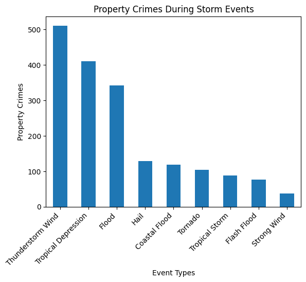

```python
event_counts.plot(kind='bar')
plt.title("Property Crimes During Storm Events")
plt.xlabel("Event Types")
plt.ylabel("Property Crimes")
plt.xticks(rotation=45, ha='right')

plt.savefig("DAT 375 Project Two_Visualization_Jonathan Hodge.png")
plt.show
```

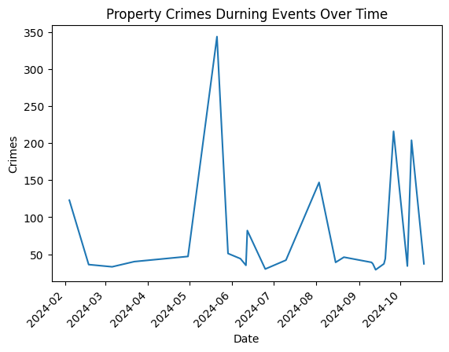

```python
merged_df['CFSDate'] = pd.to_datetime(merged_df['CFSDate'])

time_frame = merged_df.groupby('CFSDate').size()

time_frame.plot(kind='line')
plt.title("Property Crimes Durning Events Over Time")
plt.xlabel("Date")
plt.ylabel("Crimes")

plt.xticks(rotation=45, ha='right')

plt.savefig("DAT 375 Project Two_Second_Visualization_Jonathan Hodge.png")
plt.show()
```

## Step 6: Save cleaned dataset and visualizations

You will save the cleaned dataset from your analysis to a .`csv` in the format `DAT 375 Project Two_Visualization_<your name>.csv` and visuals created to be saved as a `.png` picture file following the name convention replacing with your name: `DAT 375 Project Two_Visualization_<your name>.png`

```python
merged_df.to_csv("DAT 375 ProjectTwo_Visualization_Jonathan Hodge.csv", index=False, encoding='utf-8-sig')
```

## End of Lab

Please confirm that you have completed each of the asks and include necessary information for your Discussion response.

It is a good habit to confirm that all cells run when done with your analysis in a Jupyter Notebook. You also may find that the code has an error that was not realized due changes in your work throughout. To do this, please go to the top menu bar:

**Kernel** --> **Restart Kernel and Run All Cells**

Did you make it back here with all cells running without error?

Please also complete all required screenshots and any files you needed to create.

Please confirm that you have saved all of your work for this lab within the `MyWork` folder.